# Analysis Example 2: Intervention

# Overview

Each of these pages provides an analysis run through for a different type of design. Each document is structured in the same way. First the data is introduced. For the purpose of these tutorials, I will only use examples where the data can be shared - either because it is from an open access publication, or because it is unpublished or simulated. Second, the structure of the data is discussed so that we can more easily see what data structure the design creates, and how this aligns to the variables in the data. Third, we translate the research questions into formal equations, and then `lmer()` code. Finally, we will follow those through for our example data.

# Analysis

```r
library(tidyverse)
library(lme4)
library(kableExtra)
```

## Tidy data

```r
simMIX <- tibble(
  ID = factor(rep(paste("ID", 1:50, sep=""),each=3)) ,
  Stress = round(c(rnorm(75,c(40,45,42),sd=c(4, 6, 5)),rnorm(75,c(90,60,20),sd=c(6, 10, 5))),0),
  Time = factor(rep(c("Pre", "During", "Post"), each=1,50)),
  Group = factor(c(rep("Control", 75), rep("Treatment", 75)))
)

simMIX[c(1:3, 148:150),]
```

| ID | Stress | Time | Group |
| --- | --- | --- | --- |
| ID1 | 33 | Pre | Control |
| ID1 | 44 | During | Control |
| ID1 | 50 | Post | Control |
| ID50 | 83 | Pre | Treatment |
| ID50 | 47 | During | Treatment |
| ID50 | 19 | Post | Treatment |

## Describe

We now have two factors of interest, scores over `Time` and by `Group`. So we do our descriptive statistics by multiple grouping factors.

```r
sumMIX <-
  simMIX %>%
  group_by(Time, Group) %>%
  summarise(
    N = n_distinct(ID),
    Mean = round(mean(Stress, na.rm=T),2),
    SD = round(sd(Stress, na.rm=T),2)
    )
```

```r
kable(sumMIX) %>%
  kable_styling("striped")
```

| Time | Group | N | Mean | SD |
| --- | --- | --- | --- | --- |
| During | Control | 25 | 47.44 | 5.60 |
| During | Treatment | 25 | 62.80 | 10.40 |
| Post | Control | 25 | 40.84 | 4.53 |
| Post | Treatment | 25 | 20.76 | 5.63 |
| Pre | Control | 25 | 39.88 | 4.94 |
| Pre | Treatment | 25 | 89.52 | 6.04 |

## Visualize

We can use a similar violin plot to visualise our data.

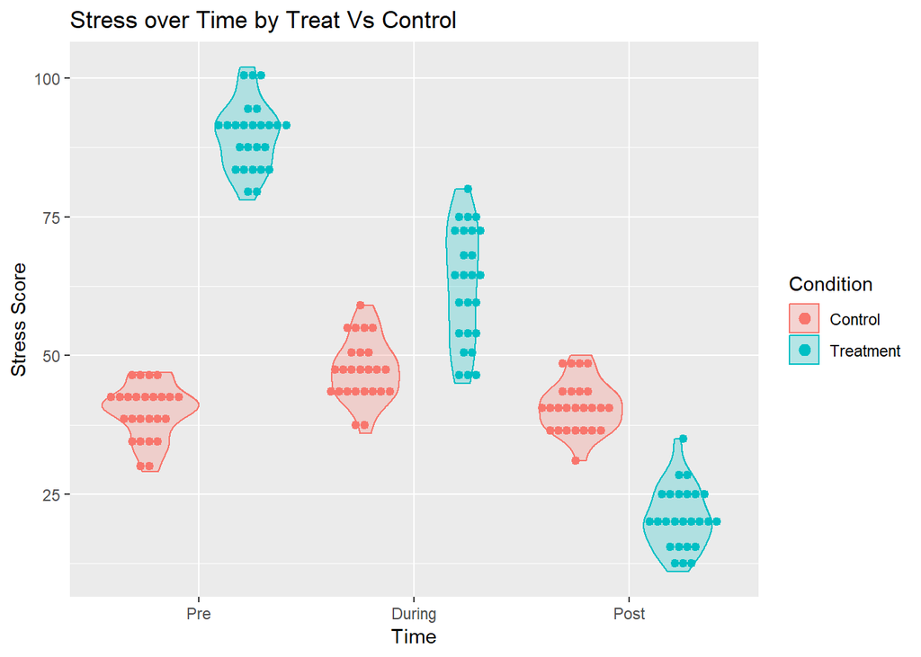

```r
simMIX %>%
  ggplot(aes(Time, Stress, color=Group, fill=Group))  +
  geom_violin(alpha = .25) +
  geom_dotplot(binaxis='y', stackdir='center', position=position_dodge(1),
               dotsize = 0.5) +
  scale_x_discrete(limits = c("Pre", "During", "Post")) +
  labs(x="Time", y = "Stress Score",
       title="Stress over Time by Treat Vs Control", color="Condition", fill="Condition")
```

It is useful to note that the violin plot contains much of the same information that a more traditional boxplot would have, but provides more information on the actual distribution with groups as it draws on density plots.

What we can see here is that over time, the control group shows little change, but the treatment group shows distinct declines.

## Run models

Base model:

```r
m0 <- lmer(Stress ~ 1 +
             (1 | ID), data = simMIX)
summary(m0)
```

```
## Linear mixed model fit by REML ['lmerMod']
## Formula: Stress ~ 1 + (1 | ID)
##    Data: simMIX
##
## REML criterion at convergence: 1355.6
##
## Scaled residuals:
##     Min      1Q  Median      3Q     Max
## -1.7429 -0.5871 -0.2759  0.6021  2.3025
##
## Random effects:
##  Groups   Name        Variance Std.Dev.
##  ID       (Intercept)   0       0.00
##  Residual             506      22.49
## Number of obs: 150, groups:  ID, 50
##
## Fixed effects:
##             Estimate Std. Error t value
## (Intercept)   50.207      1.837   27.34
```

Main effects:

```r
m1 <- lmer(Stress ~ 1 + Time + Group +
             (1 | ID), data = simMIX)
summary(m1)
```

```
## Linear mixed model fit by REML ['lmerMod']
## Formula: Stress ~ 1 + Time + Group + (1 | ID)
##    Data: simMIX
##
## REML criterion at convergence: 1235.6
##
## Scaled residuals:
##      Min       1Q   Median       3Q      Max
## -1.78568 -0.91942  0.02405  0.86626  1.88695
##
## Random effects:
##  Groups   Name        Variance Std.Dev.
##  ID       (Intercept)   0.0     0.0
##  Residual             249.6    15.8
## Number of obs: 150, groups:  ID, 50
##
## Fixed effects:
##                Estimate Std. Error t value
## (Intercept)       47.63       2.58  18.462
## TimePost         -24.32       3.16  -7.696
## TimePre            9.58       3.16   3.032
## GroupTreatment    14.97       2.58   5.803
##
## Correlation of Fixed Effects:
##             (Intr) TimPst TimePr
## TimePost    -0.612
## TimePre     -0.612  0.500
## GroupTrtmnt -0.500  0.000  0.000
```

Interaction:

```r
m2 <- lmer(Stress ~ 1 + Time + Group + Time*Group +
             (1 | ID), data = simMIX)
summary(m2)
```

```
## Linear mixed model fit by REML ['lmerMod']
## Formula: Stress ~ 1 + Time + Group + Time * Group + (1 | ID)
##    Data: simMIX
##
## REML criterion at convergence: 964.8
##
## Scaled residuals:
##     Min      1Q  Median      3Q     Max
## -2.5783 -0.6061  0.1261  0.6243  2.6198
##
## Random effects:
##  Groups   Name        Variance Std.Dev.
##  ID       (Intercept)  4.82    2.196
##  Residual             37.28    6.106
## Number of obs: 150, groups:  ID, 50
##
## Fixed effects:
##                         Estimate Std. Error t value
## (Intercept)               47.440      1.298  36.556
## TimePost                  -6.600      1.727  -3.822
## TimePre                   -7.560      1.727  -4.377
## GroupTreatment            15.360      1.835   8.369
## TimePost:GroupTreatment  -35.440      2.442 -14.510
## TimePre:GroupTreatment    34.280      2.442  14.035
##
## Correlation of Fixed Effects:
##             (Intr) TimPst TimePr GrpTrt TmPs:GT
## TimePost    -0.665
## TimePre     -0.665  0.500
## GroupTrtmnt -0.707  0.471  0.471
## TmPst:GrpTr  0.471 -0.707 -0.354 -0.665
## TmPr:GrpTrt  0.471 -0.354 -0.707 -0.665  0.500
```

Compare all models

```r
anova(m0,m1,m2)
```

```
## refitting model(s) with ML (instead of REML)
```

|  | Df | AIC | BIC | logLik | deviance | Chisq | Chi Df | Pr(>Chisq) |
| --- | --- | --- | --- | --- | --- | --- | --- | --- |
| m0 | 3 | 1364.6599 | 1373.692 | -679.3299 | 1358.6599 | NA | NA | NA |
| m1 | 6 | 1261.6254 | 1279.689 | -624.8127 | 1249.6254 | 109.0345 | 3 | 1.77053e-23 |
| m2 | 8 | 994.7295 | 1018.815 | -489.3647 | 978.7295 | 270.8959 | 2 | 1.49869e-59 |

As we did with the simple repeated measures, we can also compare the sums of squares breakdown for the LMM (`m2`) by calling `anova()` on the `lmer()` model.

First with `aov()`:

```r
m3 <- aov(Stress ~ Time + Group + Time*Group +
            Error(ID/Time), data = simMIX)
summary(m3)
```

```
##
## Error: ID
##           Df Sum Sq Mean Sq F value Pr(>F)
## Group      1   8408    8408   162.5 <2e-16 ***
## Residuals 48   2484      52
## ---
## Signif. codes:  0 '***' 0.001 '**' 0.01 '*' 0.05 '.' 0.1 ' ' 1
##
## Error: ID:Time
##            Df Sum Sq Mean Sq F value Pr(>F)
## Time        2  30541   15270   409.6 <2e-16 ***
## Time:Group  2  30383   15192   407.5 <2e-16 ***
## Residuals  96   3579      37
## ---
## Signif. codes:  0 '***' 0.001 '**' 0.01 '*' 0.05 '.' 0.1 ' ' 1
```

And then summarise:

```r
anova(m2)
```

|  | Df | Sum Sq | Mean Sq | F value |
| --- | --- | --- | --- | --- |
| Time | 2 | 30540.813 | 15270.407 | 409.5742 |
| Group | 1 | 6057.906 | 6057.906 | 162.4817 |
| Time:Group | 2 | 30383.293 | 15191.647 | 407.4618 |